# TCGA Cancer Microbiome Analysis Pipeline

## Cancer Microbiome Data Processing and Clustering

This section provides helper functions to process TCGA microbiome data for any cancer type, normalize it using CLR or coverage-based methods, and cluster patient samples based on species richness, abundance, or both. It filters and prepares data for downstream analysis.

The script also generates and save scatter plots for TCGA microbiome data, visualizing species richness and log-transformed abundance across samples for a specified cancer type and state. Plots include variations with shipping center colors and quantile-based grouping.

```r
# Extract samples for a specific cancer type and state
get_samples <- function(cancer_name, state) {
  qcMet['SampleID'] <- rownames(qcMet)  # Add SampleID column

  # Filter metadata by cancer, state, and exclude specific source
  filtered_samples <- qcMet %>%
    filter(data_submitting_center_label != "University of North Carolina", investigation == cancer_name, sample_type == state)

  # Filter OTU counts based on matching samples
  matching_row_names <- colnames(counts) %in% filtered_samples$SampleID
  counts_filt <- counts[matching_row_names]
  counts_filt <- counts_filt[rowSums(counts_filt) >= 500, ]  # Remove low-abundance taxa
  counts_filt <- counts_filt[, colSums(counts_filt) > 0]     # Remove zero-sum samples

  # Filter taxonomy and immune data
  matching_row_names <- rownames(counts_filt) %in% rownames(tax)
  tax_filt <- tax[matching_row_names, ]
  matching_index <- which(rownames(immune_tcga) %in% filtered_samples$tcga_case_id)
  immune_tcga_filt <- immune_tcga[matching_index, ]

  # Create phyloseq objects (raw and processed)
  otda <- as.matrix.data.frame(counts_filt)
  OTU <- phyloseq::otu_table(otda, taxa_are_rows = TRUE)
  tax_t <- as.matrix.data.frame(tax_filt)
  taxda <- phyloseq::tax_table(tax_t)
  sample <- phyloseq::sample_data(filtered_samples)
  ps_tumor_raw <- phyloseq::phyloseq(OTU, sample, taxda)
  ps_tumor <- phyloseq::phyloseq(OTU, sample, taxda)
  sample_ids <- names(counts_filt)

  # Return list of outputs
  return(c(ps_tumor_raw = ps_tumor_raw, ps_tumor = ps_tumor, filtered_samples = filtered_samples,
           sample_ids = sample_ids, tax_filt = tax_filt))
}

# Normalize phyloseq object using CLR transformation
normalize_ps <- function(ps_tumor) {
  cts <- ps_tumor@otu_table
  sample_totals <- colSums(cts)
  relative_abundance <- cts / sample_totals
  xt <- clr(relative_abundance)  # Centered log-ratio transform
  OTU <- phyloseq::otu_table(xt, taxa_are_rows = TRUE)
  sample <- phyloseq::sample_data(ps_tumor@sam_data)
  taxTable <- phyloseq::tax_table(ps_tumor@tax_table)
  return(phyloseq::phyloseq(OTU, sample, taxTable))
}

# Normalize phyloseq object using coverage data
normalize_ps_coverage <- function(ps_tumor) {
  cts <- ps_tumor@otu_table
  coverage <- as.numeric(ps_tumor@sam_data$total)  # Use total reads for normalization
  relative_abundance <- cts / coverage
  xt <- relative_abundance  # No log transform here
  print("log has been taken")  # Note: Misleading message, no log applied
  OTU <- phyloseq::otu_table(xt, taxa_are_rows = TRUE)
  sample <- phyloseq::sample_data(ps_tumor@sam_data)
  taxTable <- phyloseq::tax_table(ps_tumor@tax_table)
  return(phyloseq::phyloseq(OTU, sample, taxTable))
}

# Prepare data frame for plotting richness and abundance
plot_data_df <- function(ps_clr) {
  tumor_counts <- phyloseq::otu_table(ps_clr)
  observed_richness <- colSums(tumor_counts > 0)  # Species richness
  if (!is.null(ps_clr@sam_data$Group)) {
    plot_data <- data.frame(species_richness = observed_richness, CLR_abundance = log(colSums(tumor_counts)),
                            shipping_labels = ps_clr@sam_data$data_submitting_center_label, Group = ps_clr@sam_data$Group)
  } else {
    plot_data <- data.frame(species_richness = observed_richness, CLR_abundance = log(colSums(tumor_counts)),
                            shipping_labels = ps_clr@sam_data$data_submitting_center_label)
    phyloseq::sample_data(ps_clr)$microbiome_richness <- colSums(tumor_counts > 0)
    phyloseq::sample_data(ps_clr)$microbiome_abundance <- log(colSums(tumor_counts))
  }
  return(c(list(plot_data = plot_data, ps_clr = ps_clr)))
}

# Cluster samples by abundance only
assign_groups_abundance <- function(plot_data, ps_tumor_clr) {
  # Define low and high abundance groups based on quantiles
  samples_in_low_richness <- plot_data[plot_data$CLR_abundance < quantile(plot_data$CLR_abundance, prob = 0.25), ]
  samples_in_high_richness <- plot_data[plot_data$CLR_abundance > quantile(plot_data$CLR_abundance, prob = 0.75), ]

  # Label groups
  samples_in_low_richness$QuantileLabel <- "Low"
  samples_in_high_richness$QuantileLabel <- "High"
  not_used_samples <- plot_data[!(row.names(plot_data) %in% row.names(samples_in_low_richness) |
                                    row.names(plot_data) %in% row.names(samples_in_high_richness)), ]
  not_used_samples$QuantileLabel <- "not_used_samples"

  # Combine and align with phyloseq object
  combined_samples <- rbind(samples_in_low_richness, samples_in_high_richness, not_used_samples)
  combined_samples_reordered <- combined_samples[rownames(phyloseq::sample_data(ps_tumor_clr)), ]
  phyloseq::sample_data(ps_tumor_clr)$Group <- combined_samples_reordered$QuantileLabel

  # Add richness and abundance to sample data
  ps_sample_names <- rownames(phyloseq::sample_data(ps_tumor_clr))
  ordered_plot_data <- plot_data[match(ps_sample_names, rownames(plot_data)), ]
  phyloseq::sample_data(ps_tumor_clr)$Microbiome_Richness <- ordered_plot_data$species_richness
  phyloseq::sample_data(ps_tumor_clr)$Microbiome_Abundance <- ordered_plot_data$CLR_abundance

  return(list(ps_tumor_clr = ps_tumor_clr, combined_samples = combined_samples_reordered))
}

# Cluster samples by richness only
assign_groups_richness <- function(plot_data, ps_tumor_clr) {
  # Define low and high richness groups based on quantiles
  samples_in_low_richness <- plot_data[plot_data$species_richness < quantile(plot_data$species_richness, prob = 0.25), ]
  samples_in_high_richness <- plot_data[plot_data$species_richness > quantile(plot_data$species_richness, prob = 0.75), ]

  # Label groups
  samples_in_low_richness$QuantileLabel <- "Low"
  samples_in_high_richness$QuantileLabel <- "High"
  not_used_samples <- plot_data[!(row.names(plot_data) %in% row.names(samples_in_low_richness) |
                                    row.names(plot_data) %in% row.names(samples_in_high_richness)), ]
  not_used_samples$QuantileLabel <- "not_used_samples"

  # Combine and align with phyloseq object
  combined_samples <- rbind(samples_in_low_richness, samples_in_high_richness, not_used_samples)
  combined_samples_reordered <- combined_samples[rownames(phyloseq::sample_data(ps_tumor_clr)), ]
  phyloseq::sample_data(ps_tumor_clr)$Group <- combined_samples_reordered$QuantileLabel
```

```r
  # Add richness and abundance to sample data
  ps_sample_names <- rownames(phyloseq::sample_data(ps_tumor_clr))
  ordered_plot_data <- plot_data[match(ps_sample_names, rownames(plot_data)), ]
  phyloseq::sample_data(ps_tumor_clr)$Microbiome_Richness <- ordered_plot_data$species_richness
  phyloseq::sample_data(ps_tumor_clr)$Microbiome_Abundance <- ordered_plot_data$CLR_abundance

  return(list(ps_tumor_clr = ps_tumor_clr, combined_samples = combined_samples_reordered))
}

# Cluster samples by both richness and abundance
assign_groups_richness_abundance <- function(plot_data, ps_tumor_clr) {
  # Define low and high groups based on both richness and abundance quantiles
  samples_in_low_richness <- plot_data[plot_data$species_richness < quantile(plot_data$species_richness, prob = 0.25) &
                                         plot_data$CLR_abundance < quantile(plot_data$CLR_abundance, prob = 0.25), ]
  samples_in_high_richness <- plot_data[plot_data$species_richness > quantile(plot_data$species_richness, prob = 0.75) &
                                          plot_data$CLR_abundance > quantile(plot_data$CLR_abundance, prob = 0.75), ]

  # Label groups
  samples_in_low_richness$QuantileLabel <- "Low"
  samples_in_high_richness$QuantileLabel <- "High"
  not_used_samples <- plot_data[!(row.names(plot_data) %in% row.names(samples_in_low_richness) |
                                    row.names(plot_data) %in% row.names(samples_in_high_richness)), ]
  not_used_samples$QuantileLabel <- "not_used_samples"

  # Combine and align with phyloseq object
  combined_samples <- rbind(samples_in_low_richness, samples_in_high_richness, not_used_samples)
  combined_samples_reordered <- combined_samples[rownames(phyloseq::sample_data(ps_tumor_clr)), ]
  phyloseq::sample_data(ps_tumor_clr)$Group <- combined_samples_reordered$QuantileLabel

  # Add richness and abundance to sample data
  ps_sample_names <- rownames(phyloseq::sample_data(ps_tumor_clr))
  ordered_plot_data <- plot_data[match(ps_sample_names, rownames(plot_data)), ]
  phyloseq::sample_data(ps_tumor_clr)$Microbiome_Richness <- ordered_plot_data$species_richness
  phyloseq::sample_data(ps_tumor_clr)$Microbiome_Abundance <- ordered_plot_data$CLR_abundance

  return(list(ps_tumor_clr = ps_tumor_clr, combined_samples = combined_samples_reordered))
}

# Cluster samples randomly for control comparison
assign_groups_random <- function(plot_data, ps_tumor_clr) {
  # Shuffle data for random assignment
  shuffled_data <- plot_data[sample(nrow(plot_data)), ]
  total_samples <- nrow(shuffled_data)
  low_high_samples <- floor(total_samples * 0.4)  # 40% split for low/high
  not_used_samples_count <- total_samples - (2 * low_high_samples)

  # Randomly select low and high groups
  low_richness_samples <- shuffled_data[sample(nrow(shuffled_data), size = low_high_samples), ]
  high_richness_samples <- shuffled_data[!(rownames(shuffled_data) %in% row.names(low_richness_samples)), ][
    sample(nrow(shuffled_data) - nrow(low_richness_samples), size = low_high_samples), ]

  # Handle remaining samples
  not_used_samples_df <- shuffled_data[!(rownames(shuffled_data) %in% row.names(low_richness_samples) |
                                           rownames(shuffled_data) %in% row.names(high_richness_samples)), ]
  if (nrow(not_used_samples_df) > not_used_samples_count) {
    not_used_samples_df <- not_used_samples_df[sample(nrow(not_used_samples_df), size = not_used_samples_count), ]
  }

  # Label groups
  low_richness_samples$QuantileLabel <- "Low"
  high_richness_samples$QuantileLabel <- "High"
  not_used_samples_df$QuantileLabel <- "Not Used"

  # Combine and align with phyloseq object
  combined_samples <- rbind(low_richness_samples, high_richness_samples, not_used_samples_df)
  combined_samples_reordered <- combined_samples[rownames(phyloseq::sample_data(ps_tumor_clr)), ]
  phyloseq::sample_data(ps_tumor_clr)$Group <- combined_samples_reordered$QuantileLabel

  return(list(ps_tumor_clr = ps_tumor_clr, combined_samples = combined_samples))
}

# Filter phyloseq objects to keep only High/Low groups
filtered_ps <- function(ps_tumor_clr, ps_tumor_raw) {
  ps_tumor_filtered <- subset_samples(ps_tumor_clr, Group %in% c("High", "Low"))
  sample_data(ps_tumor_raw)$Group <- sample_data(ps_tumor_clr)$Group
  ps_tumor_raw <- subset_samples(ps_tumor_raw, Group %in% c("High", "Low"))
  return(c(ps_tumor_filtered = ps_tumor_filtered, ps_tumor_raw = ps_tumor_raw))
}


# Generate richness and abundance plots for a cancer type and state
generate_richness_abundance_plots <- function(cancer_name, state, path_to_save) {
  # Define color mapping for shipping centers
  color_mapping <- c(
    "Washington University School of Medicine" = "#66c2a5",        # Greenish Blue
    "Broad Institute of MIT and Harvard" = "#fc8d62",             # Salmon
    "Baylor College of Medicine" = "#8da0cb",                     # Light Blue
    "Harvard Medical School" = "#e78ac3",                        # Pinkish
    "MD Anderson - Institute for Applied Cancer Science" = "#a6d854", # Light Green
    "MD Anderson - RPPA Core Facility (Proteomics)" = "#ffd92f",  # Yellow
    "University of North Carolina" = "#e5c494",                   # Beige
    "Canada's Michael Smith Genome Sciences Centre" = "#b3b3b3"   # Gray
  )

  # Basic richness vs. abundance scatter plot
  richness_abundnace <- ggplot(plot_data$plot_data, aes(x = species_richness, y = CLR_abundance)) +
    geom_point(size = 4, show.legend = TRUE) +  # Scatter points
    theme_bw() +
    theme(panel.grid = element_blank()) +
    labs(x = "Observed Richness", y = "log(Abundance)") +
    theme(
      plot.title = element_text(size = 14, face = "bold"),
      axis.title = element_text(size = 14),
      axis.text = element_text(size = 12),
      legend.title = element_blank(),
      legend.text = element_text(size = 14)
    )

  # Save the basic plot
  filepath <- paste0(path_to_save, "richabun_", cancer_name, "_", state, "_plot.pdf")
  ggsave(filepath, richness_abundnace, device = "pdf", width = 8, height = 6, units = "in")
```

```r
  # Richness vs. abundance with shipping center colors
  richness_abundnace_gplot <- ggplot(plot_data$plot_data, aes(x = species_richness, y = CLR_abundance, color = shipping_labels)) +
    geom_point(size = 4, show.legend = TRUE) +
    theme_bw() +
    theme(panel.grid = element_blank()) +
    scale_color_manual(values = color_mapping) +  # Apply color mapping
    labs(x = "Observed Richness", y = "log(Abundance)") +
    theme(
      plot.title = element_text(size = 14, face = "bold"),
      axis.title = element_text(size = 14),
      axis.text = element_text(size = 12),
      legend.title = element_blank(),
      legend.text = element_text(size = 14)
    )

  # Save the colored plot
  filepath <- paste0(path_to_save, "richness_abundnace_", cancer_name, "_", state, "_gplot.pdf")
  ggsave(filepath, richness_abundnace_gplot, device = "pdf", width = 8, height = 6, units = "in")

  # Quantile-based richness vs. abundance plot
  quantile_plot <- ggplot(as_out$combined_samples, aes(x = species_richness, y = CLR_abundance, color = QuantileLabel)) +
    geom_point(size = 4) +
    geom_point(data = as_out$combined_samples[as_out$combined_samples$QuantileLabel == "not_used_samples", ],
               aes(x = species_richness, y = CLR_abundance), size = 3, shape = 1, color = "gray") +  # Highlight unused samples
    scale_color_manual(values = c("Low" = "#FD9347", "High" = "#00AED7", "not_used_samples" = "gray"),
                       breaks = c("Low", "High"), name = "Quantiles") +  # Custom colors and legend
    theme_bw() +
    theme(panel.grid = element_blank(),
          plot.title = element_text(size = 14, face = "bold"),
          axis.title = element_text(size = 16),
          axis.text = element_text(size = 12),
          legend.title = element_blank(),
          legend.text = element_text(size = 14)) +
    labs(x = "Observed Richness", y = "log(Abundance)")

  # Save the quantile plot
  filepath <- paste0(path_to_save, "quantile_", cancer_name, "_", state, "_plot.pdf")
  ggsave(filepath, quantile_plot, device = "pdf", width = 8, height = 6, units = "in")
}
```

## Differential Species Analysis with ANCOM

This section provides an ANCOM helper function for preprocessing microbiome data and identifying differentially abundant taxa, followed by a function that applies ANCOM to TCGA data, generates plots (volcano and bar charts), and highlights significant species across sample groups.

```r
# Pre-process feature table for ANCOM analysis
feature_table_pre_process <- function(feature_table, meta_data, sample_var, group_var = NULL,
                                      out_cut = 0.05, zero_cut = 0.90, lib_cut, neg_lb) {
  # Convert to data frames and align sample IDs
  feature_table <- data.frame(feature_table, check.names = FALSE)
  meta_data <- data.frame(meta_data, check.names = FALSE)
  meta_data[] <- lapply(meta_data, function(x) if(is.factor(x)) factor(x) else x)  # Drop unused levels
  sample_ID <- intersect(meta_data[, sample_var], colnames(feature_table))
  feature_table <- feature_table[, sample_ID]
  meta_data <- meta_data[match(sample_ID, meta_data[, sample_var]), ]

  # Identify and remove outliers if grouped
  if (!is.null(group_var)) {
    group <- meta_data[, group_var]
    z <- feature_table + 1
    f <- log(z); f[f == 0] <- NA
    f <- colMeans(f, na.rm = TRUE)
    f_fit <- lm(f ~ group)
    e <- rep(0, length(f)); e[!is.na(group)] <- residuals(f_fit)
    y <- t(t(z) - e)

    # Outlier detection with mixture model
    outlier_check <- function(x) {
      mu1 <- quantile(x, 0.25, na.rm = TRUE); mu2 <- quantile(x, 0.75, na.rm = TRUE)
      sigma1 <- mu2 - mu1; sigma2 <- sigma1; pi <- 0.75; n <- length(x)
      epsilon <- 100; tol <- 1e-5
      score <- pi * dnorm(x, mu1, sigma1) / ((1 - pi) * dnorm(x, mu2, sigma2))
      while (epsilon > tol) {
        grp1_ind <- (score >= 1)
        mu1_new <- mean(x[grp1_ind]); mu2_new <- mean(x[!grp1_ind])
        sigma1_new <- sd(x[grp1_ind]); if(is.na(sigma1_new)) sigma1_new <- 0
        sigma2_new <- sd(x[!grp1_ind]); if(is.na(sigma2_new)) sigma2_new <- 0
        pi_new <- sum(grp1_ind) / n
        if (any(is.na(c(mu1_new, mu2_new, sigma1_new, sigma2_new, pi_new)))) break
        score <- pi_new * dnorm(x, mu1_new, sigma1_new) / ((1 - pi_new) * dnorm(x, mu2_new, sigma2_new))
        epsilon <- sqrt(sum((c(mu1, mu2, sigma1, sigma2, pi) - c(mu1_new, mu2_new, sigma1_new, sigma2_new, pi_new))^2))
        mu1 <- mu1_new; mu2 <- mu2_new; sigma1 <- sigma1_new; sigma2 <- sigma2_new; pi <- pi_new
      }
      if (mu1 + 1.96 * sigma1 < mu2 - 1.96 * sigma2) {
        if (pi < out_cut) return(grp1_ind)
        else if (pi > 1 - out_cut) return(!grp1_ind)
        else return(rep(FALSE, n))
      } else return(rep(FALSE, n))
    }
    out_ind <- matrix(FALSE, nrow(feature_table), ncol(feature_table))
    out_ind[, !is.na(group)] <- t(apply(y, 1, function(i) unlist(tapply(i, group, outlier_check))))
    feature_table[out_ind] <- NA
  }

  # Filter taxa and samples
  zero_prop <- apply(feature_table, 1, function(x) sum(x == 0, na.rm = TRUE) / length(x[!is.na(x)]))
  taxa_del <- which(zero_prop >= zero_cut)
  if (length(taxa_del) > 0) feature_table <- feature_table[-taxa_del, ]
  lib_size <- colSums(feature_table, na.rm = TRUE)
  if (any(lib_size < lib_cut)) {
    subj_del <- which(lib_size < lib_cut)
    feature_table <- feature_table[, -subj_del]
    meta_data <- meta_data[-subj_del, ]
  }

  # Identify structural zeros if grouped
  if (!is.null(group_var)) {
    group <- factor(meta_data[, group_var])
    present_table <- as.matrix(feature_table); present_table[is.na(present_table)] <- 0; present_table[present_table != 0] <- 1
    p_hat <- t(apply(present_table, 1, function(x) unlist(tapply(x, group, mean, na.rm = TRUE))))
    samp_size <- t(apply(feature_table, 1, function(x) unlist(tapply(x, group, function(y) length(y[!is.na(y)])))))
    p_hat_lo <- p_hat - 1.96 * sqrt(p_hat * (1 - p_hat) / samp_size)
    struc_zero <- (p_hat == 0) * 1
    if (neg_lb) struc_zero[p_hat_lo <= 0] <- 1
    struc_ind <- struc_zero[, group]
    feature_table <- feature_table * (1 - struc_ind)
    colnames(struc_zero) <- paste0("structural_zero (", colnames(struc_zero), ")")
  } else {
    struc_zero <- NULL
  }

  return(list(feature_table = feature_table, meta_data = meta_data, structure_zeros = struc_zero))
}

# ANCOM: Analysis of Composition of Microbiomes
ANCOM <- function(feature_table, meta_data, struc_zero = NULL, main_var, p_adj_method = "BH",
                  alpha = 0.05, adj_formula = NULL, rand_formula = NULL, lme_control = NULL) {
  # Preprocess OTU table for ANCOM
  if (!is.null(struc_zero)) {
    num_struc_zero <- apply(struc_zero, 1, sum)
    comp_table <- feature_table[num_struc_zero == 0, ]
  } else {
    comp_table <- feature_table
  }
  comp_table <- log(as.matrix(comp_table) + 1)  # Log transform with pseudocount
  n_taxa <- dim(comp_table)[1]; taxa_id <- rownames(comp_table); n_samp <- dim(comp_table)[2]

  # Select statistical test
  if (is.null(rand_formula) & is.null(adj_formula)) {
    tfun <- if (length(unique(meta_data %>% pull(main_var))) == 2) stats::wilcox.test else stats::kruskal.test
    tformula <- formula(paste("x ~", main_var))
  } else if (is.null(rand_formula) & !is.null(adj_formula)) {
    tfun <- stats::aov
    tformula <- formula(paste("x ~", main_var, "+", adj_formula))
  } else if (!is.null(rand_formula)) {
    tfun <- nlme::lme
    tformula <- if (is.null(adj_formula)) formula(paste("x ~", main_var)) else formula(paste("x ~", main_var, "+", adj_formula))
  }

  # Compute p-values for taxon pairs
  p_data <- matrix(NA, n_taxa, n_taxa, dimnames = list(taxa_id, taxa_id))
  #pb <- txtProgressBar(0, n_taxa - 1, style = 3)
  for (i in 1:(n_taxa - 1)) {
    #setTxtProgressBar(pb, i)
    alr_data <- apply(comp_table, 1, function(x) x - comp_table[i, ])[, -(1:i), drop = FALSE]
    n_lr <- dim(alr_data)[2]
    alr_data <- cbind(alr_data, meta_data)
    if (is.null(rand_formula) & is.null(adj_formula)) {
      p_data[-(1:i), i] <- apply(alr_data[, 1:n_lr, drop = FALSE], 2, function(x) {
        suppressWarnings(tfun(tformula, data = data.frame(x, alr_data, check.names = FALSE))$p.value)
      })
    } else if (is.null(rand_formula) & !is.null(adj_formula)) {
      p_data[-(1:i), i] <- apply(alr_data[, 1:n_lr, drop = FALSE], 2, function(x) {
        summary(tfun(tformula, data = data.frame(x, alr_data, check.names = FALSE), na.action = na.omit))[[1]][main_var, "Pr(>F)"]
      })
    } else if (!is.null(rand_formula)) {
      p_data[-(1:i), i] <- apply(alr_data[, 1:n_lr, drop = FALSE], 2, function(x) {
        fit <- try(tfun(fixed = tformula, data = data.frame(x, alr_data, check.names = FALSE), random = formula(rand_formula),
                        na.action = na.omit, control = lme_control), silent = TRUE)
        if (inherits(fit, "try-error")) NA else anova(fit)[main_var, "p-value"]
      })
    }
  }
  #close(pb)
```

```r
  # Finalize p-value matrix and adjust
  p_data[upper.tri(p_data)] <- t(p_data)[upper.tri(p_data)]
  diag(p_data) <- 1; p_data[is.na(p_data)] <- 1
  q_data <- apply(p_data, 2, function(x) p.adjust(x, method = p_adj_method))
  W <- apply(q_data, 2, function(x) sum(x < alpha))  # W statistic

  # Organize output
  out_comp <- data.frame(taxa_id, W, row.names = NULL, check.names = FALSE) %>%
    mutate(detected_0.9 = W > 0.9 * (n_taxa - 1), detected_0.8 = W > 0.8 * (n_taxa - 1),
           detected_0.7 = W > 0.7 * (n_taxa - 1), detected_0.6 = W > 0.6 * (n_taxa - 1))
  if (!is.null(struc_zero)) {
    out <- data.frame(taxa_id = rownames(struc_zero), W = Inf, detected_0.9 = TRUE,
                      detected_0.8 = TRUE, detected_0.7 = TRUE, detected_0.6 = TRUE,
                      row.names = NULL, check.names = FALSE)
    out[match(taxa_id, out$taxa_id), ] <- out_comp
  } else {
    out <- out_comp
  }

  # Volcano plot with CLR differences
  clr_table <- apply(feature_table, 2, clr)
  eff_size <- apply(clr_table, 1, function(y) lm(y ~ x, data = data.frame(y = y, x = meta_data %>% pull(main_var), check.names = FALSE))$coef[-1])
  if (is.matrix(eff_size)) {
    dat_fig <- data.frame(taxa_id = out$taxa_id, t(eff_size), y = out$W, check.names = FALSE) %>%
      mutate(zero_ind = factor(ifelse(is.infinite(y), "Yes", "No"), levels = c("Yes", "No"))) %>%
      gather(key = group, value = x, rownames(eff_size))
    dat_fig$group <- sapply(dat_fig$group, function(x) gsub("x", paste0(main_var, " = "), x))
    dat_fig$y <- replace(dat_fig$y, is.infinite(dat_fig$y), n_taxa - 1)
    fig <- ggplot(dat_fig, aes(x = x, y = y)) +
      geom_point(aes(color = zero_ind)) + facet_wrap(~ group) +
      labs(x = "CLR mean difference", y = "W statistic") +
      scale_color_discrete(name = "Structural zero", drop = FALSE) +
      theme_bw() + theme(plot.title = element_text(hjust = 0.5), legend.position = "top", strip.background = element_rect(fill = "white"))
  } else {
    dat_fig <- data.frame(taxa_id = out$taxa_id, x = eff_size, y = out$W) %>%
      mutate(zero_ind = factor(ifelse(is.infinite(y), "Yes", "No"), levels = c("Yes", "No")))
    dat_fig$y <- replace(dat_fig$y, is.infinite(dat_fig$y), n_taxa - 1)
    fig <- ggplot(dat_fig, aes(x = x, y = y)) +
      geom_point(aes(color = zero_ind)) +
      labs(x = "CLR mean difference", y = "W statistic") +
      scale_color_discrete(name = "Structural zero", drop = FALSE) +
      theme_bw() + theme(plot.title = element_text(hjust = 0.5), legend.position = "top")
  }

  return(list(p_data = p_data, q_data = q_data, out = out, fig = fig))
}

# Cancer-specific ANCOM analysis
run_ancomb <- function(ps_tumor_raw, cancer_name, state, path_to_save) {
  # Extract OTU table and metadata from phyloseq object
  otu_os <- ps_tumor_raw@otu_table
  sample_df <- ps_tumor_raw@sam_data
  sample_df['sample_id'] <- rownames(ps_tumor_raw@sam_data)

  # Preprocess data for ANCOM
  feature_table <- otu_os; sample_var <- "sample_id"; group_var <- NULL
  out_cut <- 0.05; zero_cut <- 0.90; lib_cut <- 1000; neg_lb <- FALSE
  prepro <- feature_table_pre_process(feature_table, sample_df, sample_var, group_var, out_cut, zero_cut, lib_cut, neg_lb)
  feature_table <- prepro$feature_table
  meta_data <- prepro$meta_data
  struc_zero <- prepro$structure_zeros

  # Set ANCOM parameters
  main_var <- "Group"; p_adj_method <- "BH"; alpha <- 0.05
  adj_formula <- if (length(unique(sample_df$data_submitting_center_label)) == 1) "age_at_diagnosis" else
    "data_submitting_center_label + age_at_diagnosis + gender"
  rand_formula <- NULL; lme_control <- NULL

  # Run ANCOM
  res <- ANCOM(feature_table, meta_data, struc_zero, main_var, p_adj_method, alpha, adj_formula, rand_formula, lme_control)

  # Calculate cutoffs for differential abundance
  n_taxa <- ifelse(is.null(struc_zero), nrow(feature_table), sum(apply(struc_zero, 1, sum) == 0))
  cut_off <- c(0.9 * (n_taxa - 1), 0.8 * (n_taxa - 1), 0.7 * (n_taxa - 1), 0.6 * (n_taxa - 1))
  names(cut_off) <- c("detected_0.9", "detected_0.8", "detected_0.7", "detected_0.6")

  # Extract significant species
  detected_sp_index <- which(res$out$detected_0.9 == TRUE)
  detected_species <- res$out$taxa_id[detected_sp_index]
  extract_clr <- res$fig$data$x[detected_sp_index]
  detected_W <- res$out$W[detected_sp_index]
  color_list <- ifelse(extract_clr > 0, "Low", ifelse(extract_clr < 0, "High", "not_used"))

  # Enhance volcano plot with annotations
  dat_ann <- data.frame(x = min(res$fig$data$x), y = cut_off["detected_0.9"], label = "W[0.9]")
  dat_sp_id <- data.frame(x = extract_clr, y = detected_W, label = detected_species, Group = color_list)
  fig <- res$fig +
    geom_hline(yintercept = cut_off["detected_0.9"], linetype = "dashed") +
    geom_text(data = dat_ann, aes(x = x, y = y, label = label), size = 4, vjust = -0.5, hjust = 0, color = "orange", parse = TRUE) +
    geom_vline(xintercept = 0, linetype = "dashed") +
    geom_text(data = dat_sp_id, aes(x = x, y = y, label = label), size = 2, box.padding = 0.5, color = "black") +
    geom_vline(xintercept = 0, linetype = "dashed") +
    theme(panel.grid = element_blank())

  # Save volcano plot
  filepath <- paste0(path_to_save, "ancomb_w_statistic", state, "_plot.jpeg")
  ggsave(filepath, fig, device = "jpeg", width = 8, height = 6, units = "in")

  # Bar plot for significant species
  top_extreme_species <- dat_sp_id[order(abs(dat_sp_id$y)), ][1:length(dat_sp_id$label), ]
  top_extreme_species <- top_extreme_species[(abs(top_extreme_species$x) > 0), ]
  top_extreme_species$label <- str_replace(top_extreme_species$label, "_", " ")
  binary_palette <- c("#8E7CC3", "#6B8E6E")  # Purple and Green

  clr_plot <- ggplot(top_extreme_species, aes(x = x, y = reorder(label, x), fill = Group)) +
    geom_bar(stat = "identity", width = 0.7) +
    scale_fill_manual(values = binary_palette) +
    labs(x = "CLR Mean Difference", y = "Species") +
    ggtitle("") +
    theme_minimal() +
    theme(panel.grid = element_blank(), axis.text.y = element_text(size = 12), axis.text.x = element_text(size = 14),
          axis.title = element_text(size = 14), axis.ticks.x = element_line(size = 0.2),
          plot.margin = margin(10, 50, 10, 30, "pt"))
```

```r
  # Save bar plot
  print(clr_plot)
  filepath <- paste0(path_to_save, "ancomb_clr_species", state, "_plot.pdf")
  ggsave(filepath, clr_plot, device = "pdf", width = 8, height = 6, units = "in", dpi = 300)

  return(top_extreme_species)
}
```

## Main TCGA Cancer Microbiome Analysis Workflow

```
[1] "log has been taken"
```

```
[1] 11160    33
[1] 187  53
```

```
[1] "**************************************************************************************************************************"
```

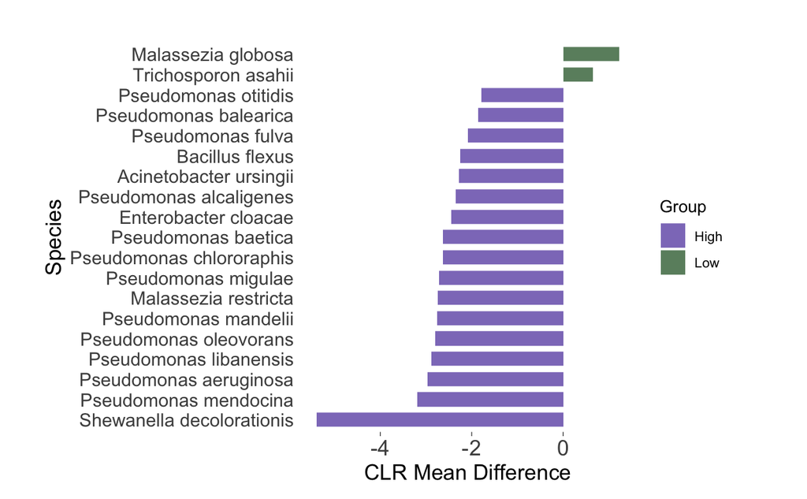

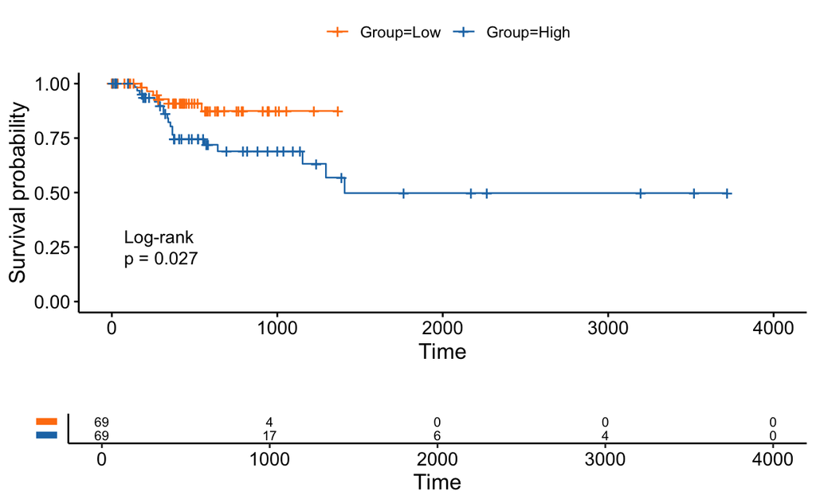

```r
# Load required libraries
library(phyloseq)      # Phyloseq objects
library(dplyr)         # Data manipulation
library(stringr)       # String operations
library(survival)      # Survival analysis
library(survminer)     # Survival plotting
library(nlme)          # Nonlinear models

# Define cancer types to analyze
tissues <- c("TCGA-STAD")

for (cancer_name in tissues) {
  cancer_name <- "TCGA-STAD"  # Example cancer type
  state <- "Tumor"            # Sample state
  path_to_save <- "/Users/eemanabbasi/Desktop/Paper_2/Manuscript_plots/abundance_only/"  # Output directory

  # Extract and process samples
  output <- get_samples(cancer_name, state)
  tcga_sample_id <- output$filtered_samples$tcga_aliquot_id

  # Normalize data using coverage-based method
  cov_ps <- normalize_ps_coverage(output$ps_tumor)

  # Generate plot data and cluster samples
  plot_data <- plot_data_df(cov_ps)
  as_out <- assign_groups_richness_abundance(plot_data$plot_data, plot_data$ps_clr)

  # Filter phyloseq objects for High/Low groups
  filt_clr_ps <- filtered_ps(as_out$ps_tumor_clr, output$ps_tumor_raw)
  filt_plot_data <- plot_data_df(filt_clr_ps$ps_tumor_filtered)

  # Save metadata
  metadata <- data.frame(filt_clr_ps$ps_tumor_filtered@sam_data)
  file_name <- paste0(path_to_save, "metadata_", cancer_name, ".txt")
  write.table(metadata, file = file_name, sep = "\t", quote = FALSE, row.names = TRUE)

  # Perform ANCOM analysis
  run_ancomb(filt_clr_ps$ps_tumor_raw, cancer_name, state, path_to_save)

  # Create High and Low phyloseq subsets for co-occurrence analysis
  ps_high <- subset_samples(filt_clr_ps$ps_tumor_filtered, Group == "High")
  ps_low <- subset_samples(filt_clr_ps$ps_tumor_filtered, Group == "Low")

  # Survival Analysis
  PATH <- "/Users/eemanabbasi/Desktop/paper_2/thesis_project_second_microbiome_analysis/m_analysis/TCGA_analysis/mycobiome/Final_files/"
  DATA <- paste0(PATH, "survival/data/")
  RESULTS <- paste0(PATH, "survival/results/")
  SCRIPTS <- paste0(PATH, "survival/scripts/")

  # Load clinical data
  clinical_filename <- "TCGA-CDR-CELL-2018.txt"
  clinical <- read.delim(paste0(DATA, clinical_filename), sep = "\t")

  # Merge clinical with metadata
  metadata['bcr_patient_barcode'] <- str_sub(metadata$tcga_sample_id, 0, 12)
  df <- merge(clinical, metadata, by = 'bcr_patient_barcode')

  print(dim(clinical))
  print(dim(metadata))

  # Filter and prepare survival data
  keep_pats <- which((df$DSS != "#N/A" & df$DSS.time != "#N/A"))
  df <- df[keep_pats, ]
  df <- df[complete.cases(df$Subtype), ]
  df <- df[!df$Subtype %in% c("STAD_POLE", "STAD_EBV"), ]
  df$status <- grepl("1", df$DSS, ignore.case = TRUE)
  surv_object <- Surv(as.numeric(df$DSS.time), event = df$status)

  # Nonlinear model for microbiome impact
  nonlinear_model <- nls(as.numeric(DSS.time) ~ a * microbiome_abundance + b * microbiome_richness,
                         data = df, start = list(a = 1, b = 1))
  summary(nonlinear_model)

  # Cox proportional hazards model
  df <- within(df, {
    Group <- relevel(as.factor(Group), ref = "Low")
    Subtype <- relevel(as.factor(Subtype), ref = "STAD_CIN")
  })
  fit_cox <- coxph(Surv(as.numeric(df$DSS.time), event = df$status) ~ Group + age_at_diagnosis + Subtype, data = df)
  summary_cox <- summary(fit_cox)

  # Survival plot if data exists
  if (nrow(df) != 0) {
    fit1 <- survfit(surv_object ~ Group, data = df)
    surv_diff_test <- survdiff(surv_object ~ Group, data = df)
    p_values <- p.adjust(surv_diff_test$pchisq, method = "fdr")

    # Generate survival plot
    plot <- ggsurvplot(
      fit1, data = df, size = 0.5, palette = c("#FF7F0E", "#1F77B4"), conf.int = FALSE,
      pval = TRUE, pval.method = TRUE, pval.size = 4, pval.adjust.method = "fdr",
      risk.table = TRUE, risk.table.col = "black", risk.table.title = "",
      legend.title = "", risk.table.height = 0.26, risk.table.fontsize = 3, risk.table.y.text = FALSE
    )

    # Add FDR p-value annotation
    annotation <- geom_text(aes(x = 0.5, y = 0.2, label = paste("FDR p-value =", round(p_values, 3))),
                            size = 3, box.padding = 0.5, direction = "both")
    plot_list <- plot

    # Save plot
    #pdf(file = paste0(path_to_save, "surv_", cancer_name, "_", state, "_plot.pdf"))
    print(plot)
    #dev.off()
    print("**************************************************************************************************************************")
  }
}
```

## Logistic Regression Analysis - clinical survival status vs. microbiome richness and abundance

Logistic Regression Analysis of TCGA Microbiome and Tumor Status This section preprocesses TCGA clinical data, fits logistic regression models to predict tumor status (Tumor Free vs. With Tumor) using microbiome richness, abundance, and age-related variables.

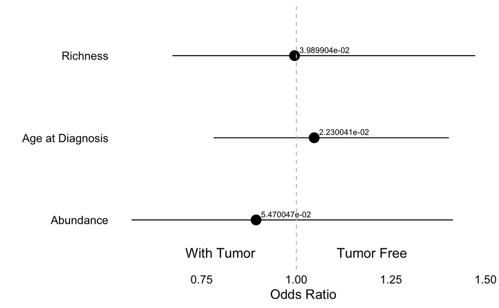

```r
library(tidyverse)  # For data manipulation
library(caret)      # For model training and evaluation
data = df

keep_pats <- which((data$DSS != "#N/A" & data$DSS.time != "#N/A" & data$tumor_status != "#N/A"))
data <- data[keep_pats,]

data <- data[complete.cases(data$Subtype), ]
data <- data[complete.cases(data$tumor_status), ]

data <- data[data$Subtype != "STAD_POLE", ]
data <- data[data$Subtype != "STAD_EBV", ]
data <- data[data$tumor_status != "[Discrepancy]", ]

data$DSS_time <- as.numeric(data$DSS.time)

# Subset data to include only observations within the first 5 years
data_subset <- data

# Determine survival status based on DSS time
# Convert "WITH TUMOR" to 0, "TUMOR FREE" to 1, and leave NA as NA
data_subset$status <- ifelse(data_subset$tumor_status == "TUMOR FREE", 1,
                             ifelse(data_subset$tumor_status == "WITH TUMOR", 0,
                                    NA))

# Fit logistic regression model using the subsetted data
logit_model_richness <- glm( status ~ microbiome_richness,
                             data = data_subset,
                             family = binomial(link = "logit"))

logit_model_abundance <- glm(status ~ microbiome_abundance,
                             data = data_subset,
                             family = binomial(link = "logit"))

logit_model_age <- glm(status ~ initial_pathologic_dx_year,
                       data = data_subset,
                       family = binomial(link = "logit"))

logit_model_age_diagnosis <- glm(status ~ age_at_diagnosis,
                                 data = data_subset,
                                 family = binomial(link = "logit"))

# Generate a sequence of values for microbiome_richness
microbiome_seq <- seq(min(data_subset$microbiome_abundance), max(data_subset$microbiome_abundance), length.out = 1000)

# Calculate the predicted probabilities
predicted_probabilities <- predict(logit_model_abundance, newdata = data.frame(microbiome_abundance = microbiome_seq), type = "response")

# Plot the logistic curve
#plot(data_subset$microbiome_abundance, data_subset$status, xlab = "Microbiome Abundance", ylab = "Status (0 = With Tumor, 1 = Tumor Free)", pch = 16)
#lines(microbiome_seq, predicted_probabilities, col = "red", type = "l")

# Extract coefficients and p-values for each model
coef_summary_richness <- summary(logit_model_richness)$coefficients[, c("Estimate", "Pr(>|z|)")]
coef_summary_abundance <- summary(logit_model_abundance)$coefficients[, c("Estimate", "Pr(>|z|)")]
coef_summary_age_diagnosis <- summary(logit_model_age_diagnosis)$coefficients[, c("Estimate", "Pr(>|z|)")]

# Combine coefficients and p-values into a single dataframe
coef_summary <- data.frame(
  Model = c("Richness", "Abundance", "Age at Diagnosis"),
  Estimate = c(coef_summary_richness["microbiome_richness", "Estimate"],
               coef_summary_abundance["microbiome_abundance", "Estimate"],
               coef_summary_age_diagnosis["age_at_diagnosis", "Estimate"]),
  Odds_Ratio = c(exp(coef_summary_richness["microbiome_richness", "Estimate"]),
                 exp(coef_summary_abundance["microbiome_abundance", "Estimate"]),
                 exp(coef_summary_age_diagnosis["age_at_diagnosis", "Estimate"])),
  P_Value = c(coef_summary_richness["microbiome_richness", "Pr(>|z|)"],
              coef_summary_abundance["microbiome_abundance", "Pr(>|z|)"],
              coef_summary_age_diagnosis["age_at_diagnosis", "Pr(>|z|)"])
)

library(ggplot2)

# Define colors and point size
point_color <- "black"
line_color <- "black"
text_color <- "black"
dot_size <- 1

odd <- ggplot(coef_summary, aes(x = Model, y = Odds_Ratio,
                                ymin = exp(Estimate - 1.96 * sqrt(P_Value)),
                                ymax = exp(Estimate + 1.96 * sqrt(P_Value)))) +
  geom_pointrange(color = point_color, size = dot_size) +
  geom_hline(yintercept = 1, linetype = "dashed", color = "grey") +
  labs(x = "", y = "Odds Ratio") +
  theme_minimal(base_size = 14) +
  theme(axis.text.y = element_text(size = 12, color = text_color),  # Adjust font size and color for y-axis
        axis.text.x = element_text(size = 12, color = text_color),  # Adjust font size and color for x-axis
        axis.line = element_blank(),  # Remove axis lines
        panel.grid.major = element_blank(),  # Remove major grid lines
        panel.grid.minor = element_blank(),  # Remove minor grid lines
        plot.title = element_text(size = 16, color = text_color, hjust = 0.5, face = "bold"),  # Title font size, color, and bold
        plot.subtitle = element_text(size = 14, color = text_color, hjust = 0.5),  # Subtitle font size and color
        plot.caption = element_text(size = 10, color = text_color, hjust = 1),  # Caption font size and color
        axis.title.y = element_text(size = 14, color = text_color),  # Y-axis title font size and color
        axis.title.x = element_text(size = 14, color = text_color),  # X-axis title font size and color
        plot.background = element_rect(fill = "white", color = NA),  # Plot background color
        panel.background = element_rect(fill = "white", color = NA),  # Panel background color
        panel.border = element_blank()) +  # Remove panel border
  geom_text(aes(label = format(P_Value, scientific = TRUE)),
            hjust = -0.1, vjust = -0.5, size = 3, color = text_color) +
  coord_flip() +
  annotate("text", x = 0.60, y = 0.8, label = "With Tumor", size = 5, hjust = 0.5, color = "black") +
  annotate("text", x = 0.6, y = 1.2, label = "Tumor Free", size = 5, hjust = 0.5, color = "black")

print(odd)
```

```r
#ggsave(paste0(path_to_save,"odd_tumor_status.pdf"), odd, width = 8, height = 6, units = "in", dpi = 300)
```

## TCGA-STAD Immune Differential Gene Expression Analysis Across High and Low Groups

This section integrates TCGA-STAD gene expression data with microbiome metadata, performs DESeq2 differential expression analysis between “High” and “Low” microbiome groups, generates a volcano plot, and creates box plots for significant immune genes, highlighting expression differences. It also performs Gene Set Enrichment Analysis for significant genes.

```r
# Immune gene panel
gene_immune_names <- c(
  "A2M", "ABCB1", "ABL1", "ADA", "ADORA2A", "AICDA", "AIRE", "AKT3", "ALCAM", "AMBP",
  "AMICA1", "ANP32B", "ANXA1", "APOE", "APP", "ARG1", "ARG2", "ATF1", "ATF2", "ATG10",
  "ATG12", "ATG16L1", "ATG5", "ATG7", "ATM", "AXL", "BATF", "BAX", "BCL10", "BCL2",
  "BCL2L1", "BCL6", "BID", "BIRC5", "BLK", "BLNK", "BMI1", "BST1", "BST2", "BTK",
  "BTLA", "C1QA", "C1QB", "C1QBP", "C1R", "C1S", "C2", "C3", "C3AR1", "C4B", "C4BPA",
  "C5", "C6", "C7", "C8A", "C8B", "C8G", "C9", "CAMP", "CARD11", "CARD9", "CASP1",
  "CASP10", "CASP3", "CASP8", "CCL1", "CCL11", "CCL13", "CCL14", "CCL15", "CCL16",
  "CCL17", "CCL18", "CCL19", "CCL2", "CCL20", "CCL21", "CCL22", "CCL23", "CCL24",
  "CCL25", "CCL26", "CCL27", "CCL28", "CCL3", "CCL3L1", "CCL4", "CCL5", "CCL7", "CCL8",
  "CCND3", "CCR1", "CCR2", "CCR3", "CCR4", "CCR5", "CCR6", "CCR7", "CCR9", "CCRL2",
  "CD14", "CD160", "CD163", "CD164", "CD180", "CD19", "CD1A", "CD1B", "CD1C", "CD1D",
  "CD1E", "CD2", "CD200", "CD207", "CD209", "CD22", "CD24", "CD244", "CD247", "CD27",
  "CD274", "CD276", "CD28", "CD33", "CD34", "CD36", "CD37", "CD38", "CD3D", "CD3E",
  "CD3EAP", "CD3G", "CD4", "CD40", "CD40LG", "CD44", "CD46", "CD47", "CD48", "CD5",
  "CD53", "CD55", "CD58", "CD59", "CD6", "CD63", "CD68", "CD7", "CD70", "CD74", "CD79A",
  "CD79B", "CD80", "CD81", "CD83", "CD84", "CD86", "CD8A", "CD8B", "CD9", "CD96", "CD97",
  "CD99", "CDH1", "CDH5", "CDK1", "CDKN1A", "CEACAM1", "CEACAM6", "CEACAM8", "CEBPB",
  "CFB", "CFD", "CFI", "CFP", "CHIT1", "CHUK", "CKLF", "CLEC4A", "CLEC4C", "CLEC5A",
  "CLEC6A", "CLEC7A", "CLU", "CMA1", "CMKLR1", "COL3A1", "COLEC12", "CR1", "CR2", "CREB1",
  "CREB5", "CREBBP", "CRP", "CSF1", "CSF1R", "CSF2", "CSF2RB", "CSF3", "CSF3R", "CTLA4",
  "CTSG", "CTSH", "CTSL", "CTSS", "CTSW", "CX3CL1", "CX3CR1", "CXCL1", "CXCL10", "CXCL11",
  "CXCL12", "CXCL13", "CXCL14", "CXCL16", "CXCL2", "CXCL3", "CXCL5", "CXCL6", "CXCL9",
  "CXCR1", "CXCR2", "CXCR3", "CXCR4", "CXCR5", "CXCR6", "CYBB", "CYFIP2", "CYLD", "DDX58",
  "DEFB1", "DMBT1", "DOCK9", "DPP4", "DUSP4", "DUSP6", "EBI3", "ECSIT", "EGR1", "EGR2",
  "ELANE", "ELK1", "ENG", "ENTPD1", "EOMES", "EP300", "EPCAM", "ETS1", "EWSR1", "F12",
  "F13A1", "F2RL1", "FADD", "FAS", "FCER1A", "FCER1G", "FCER2", "FCGR1A", "FCGR2A",
  "FCGR2B", "FCGR3A", "FEZ1", "FLT3", "FLT3LG", "FN1", "FOS", "FOXJ1", "FOXP3", "FPR2",
  "FUT5", "FUT7", "FYN", "GATA3", "GNLY", "GPI", "GTF3C1", "GZMA", "GZMB", "GZMH", "GZMK",
  "GZMM", "HAMP", "HAVCR2", "HCK", "HLA-A", "HLA-B", "HLA-C", "HLA-DMA", "HLA-DMB", "HLA-DOB",
  "HLA-DPA1", "HLA-DPB1", "HLA-DQA1", "HLA-DQB1", "HLA-DRA", "HLA-DRB3", "HLA-DRB4", "HLA-E",
  "HLA-G", "HMGB1", "HRAS", "HSD11B1", "ICAM1", "ICAM2", "ICAM3", "ICAM4", "ICOS", "ICOSLG",
  "IDO1", "IFI16", "IFI27", "IFI35", "IFIH1", "IFIT1", "IFIT2", "IFITM1", "IFITM2", "IFNA1",
  "IFNA17", "IFNA2", "IFNA7", "IFNA8", "IFNAR1", "IFNAR2", "IFNB1", "IFNG", "IFNGR1", "IFNL1",
  "IFNL2", "IGF1R", "IGF2R", "IGLL1", "IKBKB", "IKBKE", "IKBKG", "IL10", "IL10RA", "IL11",
  "IL11RA", "IL12A", "IL12B", "IL12RB1", "IL12RB2", "IL13", "IL13RA1", "IL13RA2", "IL15",
  "IL15RA", "IL16", "IL17A", "IL17B", "IL17F", "IL17RA", "IL17RB", "IL18", "IL18R1", "IL18RAP",
  "IL19", "IL1A", "IL1B", "IL1R1", "IL1R2", "IL1RAP", "IL1RAPL2", "IL1RL1", "IL1RL2", "IL1RN",
  "IL2", "IL21", "IL21R", "IL22", "IL22RA1", "IL22RA2", "IL23A", "IL23R", "IL24", "IL25",
  "IL26", "IL27", "IL2RA", "IL2RB", "IL2RG", "IL3", "IL32", "IL34", "IL3RA", "IL4", "IL4R",
  "IL5", "IL5RA", "IL6", "IL6R", "IL6ST", "IL7", "IL7R", "IL8", "IL9", "ILF3", "INPP5D", "IRAK1",
  "IRAK2", "IRAK4", "IRF1", "IRF2", "IRF3", "IRF4", "IRF5", "IRF7", "IRF8", "IRGM", "ISG15",
  "ISG20", "ITCH", "ITGA1", "ITGA2", "ITGA2B", "ITGA4", "ITGA5", "ITGA6", "ITGAE", "ITGAL",
  "ITGAM", "ITGAX", "ITGB1", "ITGB2", "ITGB3", "ITGB4", "ITK", "JAK1", "JAK2", "JAK3", "JAM3",
  "KIR_Activating_Subgroup_1", "KIR_Activating_Subgroup_2", "KIR_Inhibiting_Subgroup_1",
  "KIR_Inhibiting_Subgroup_2", "KIR3DL1", "KIR3DL2", "KIR3DL3", "KIT", "KLRB1", "KLRC1",
  "KLRC2", "KLRD1", "KLRF1", "KLRG1", "KLRK1", "LAG3", "LAIR2", "LAMP1", "LAMP2", "LAMP3",
  "LBP", "LCK", "LCN2", "LCP1", "LGALS3", "LIF", "LILRA1", "LILRA4", "LILRA5", "LILRB1",
  "LILRB2", "LILRB3", "LRP1", "LRRN3", "LTA", "LTB", "LTBR", "LTF", "LTK", "LY86", "LY9",
  "LY96", "LYN", "MAF", "MAP2K1", "MAP2K2", "MAP2K4", "MAP3K1", "MAP3K5", "MAP3K7", "MAP4K2",
  "MAPK1", "MAPK11", "MAPK14", "MAPK3", "MAPK8", "MAPKAPK2", "MARCO", "MASP1", "MASP2",
  "MAVS", "MBL2", "MCAM", "MEF2C", "MEFV", "MERTK", "MFGE8", "MICA", "MICB", "MIF", "MME",
  "MNX1", "MPPED1", "MR1", "MRC1", "MS4A1", "MS4A2", "MSR1", "MST1R", "MUC1", "MX1", "MYD88",
  "NCAM1", "NCF4", "NCR1", "NEFL", "NFATC1", "NFATC2", "NFATC3", "NFATC4", "NFKB1", "NFKB2",
  "NFKBIA", "NLRC5", "NLRP3", "NOD1", "NOD2", "NOS2A", "NOTCH1", "NRP1", "NT5E", "NUP107",
  "OAS3", "OSM", "PAX5", "PDCD1", "PDCD1LG2", "PDGFC", "PDGFRB", "PECAM1", "PIK3CD", "PIK3CG",
  "PIN1", "PLA2G1B", "PLA2G6", "PLAU", "PLAUR", "PMCH", "PNMA1", "POU2AF1", "POU2F2", "PPARG",
  "PPBP", "PRF1", "PRG2", "PRKCD", "PRKCE", "PSEN1", "PSEN2", "PSMB10", "PSMB7", "PSMB8",
  "PSMB9", "PSMD7", "PTGDR2", "PTGS2", "PTPRC", "PVR", "PYCARD", "RAG1", "REL", "RELA", "RELB",
  "REPS1", "RIPK2", "RORA", "RORC", "RPS6", "RRAD", "RUNX1", "RUNX3", "S100A12", "S100A7",
  "S100A8", "S100B", "SAA1", "SBNO2", "SELE", "SELL", "SELPLG", "SERPINB2", "SERPING1", "SH2B2",
  "SH2D1A", "SH2D1B", "SIGIRR", "SIGLEC1", "SLAMF1", "SLAMF6", "SLAMF7", "SLC11A1", "SMAD2",
  "SMAD3", "SMPD3", "SOCS1", "SPINK5", "SPN", "SPP1", "ST6GAL1", "STAT1", "STAT2", "STAT3",
  "STAT4", "STAT5B", "STAT6", "SYK", "SYT17", "TAB1", "TAL1", "TANK", "TAP1", "TAP2", "TAPBP",
  "TARP", "TBK1", "TBX21", "TCF7", "TFE3", "TFEB", "TFRC", "TGFB1", "TGFB2", "THBD", "THBS1",
  "THY1", "TICAM1", "TICAM2", "TIGIT", "TIRAP", "TLR1", "TLR10", "TLR2", "TLR3", "TLR4", "TLR5",
  "TLR6", "TLR7", "TLR8", "TLR9", "TNF", "TNFAIP3", "TNFRSF10B", "TNFRSF10C", "TNFRSF11A",
  "TNFRSF11B", "TNFRSF12A", "TNFRSF13B", "TNFRSF13C", "TNFRSF14", "TNFRSF17", "TNFRSF18",
  "TNFRSF1A", "TNFRSF1B", "TNFRSF4", "TNFRSF8", "TNFRSF9", "TNFSF10", "TNFSF11", "TNFSF12",
  "TNFSF13", "TNFSF13B", "TNFSF14", "TNFSF15", "TNFSF18", "TNFSF4", "TNFSF8", "TOLLIP", "TP53",
  "TPSAB1", "TRAF2", "TRAF3", "TRAF6", "TREM1", "TREM2", "TXK", "TXNIP", "TYK2", "UBC", "ULBP2",
  "USP9Y", "VCAM1", "VEGFA", "VEGFC", "XCL2", "XCR1", "YTHDF2", "ZAP70", "ZNF205"
)

# Load Libraries
library(DESeq2)          # Differential expression analysis
library(clusterProfiler) # Enrichment analysis (unused here)
library(org.Hs.eg.db)    # Human gene annotations (unused here)
library(AnnotationDbi)   # Annotation database interface (unused here)
library(edgeR)           # Normalization and CPM calculation
library(EnhancedVolcano) # Enhanced volcano plots
library(tidyverse)       # Data manipulation and ggplot2

# Load and preprocess gene expression data
expression_stad <- read.table('/Users/eemanabbasi/Desktop/TCGA.STAD.expression.txt', sep = "\t", check.names = FALSE, header = TRUE)
sample_ids <- expression_stad$sample_id
unique_aliquot_ids_metadata <- unique(filt_clr_ps$ps_tumor_filtered@sam_data$tcga_aliquot_id)
unique_sample_ids_expression <- unique(expression_stad$sample_id)
match_sampleids <- which(unique_aliquot_ids_metadata %in% unique_sample_ids_expression)

# Filter expression data for matched samples
filtered_expression_stad <- expression_stad[match_sampleids, ]
rownames(filtered_expression_stad) <- rownames(filt_clr_ps$ps_tumor_filtered@sam_data)[match_sampleids]
filtered_expression_stad <- filtered_expression_stad[, !colnames(filtered_expression_stad) %in% c("patient_id", "sample_id")]

# Prepare colData with group membership
unique_aliquot_ids_matched <- unique_aliquot_ids_metadata[match_sampleids]
group_membership <- filt_clr_ps$ps_tumor_filtered@sam_data$Group[match_sampleids]
colData <- data.frame(Group = factor(group_membership))
rownames(colData) <- rownames(filtered_expression_stad)

# Clean expression data
filtered_expression_stad_cleaned <- filtered_expression_stad[, colSums(is.na(filtered_expression_stad)) < nrow(filtered_expression_stad)]
filtered_expression_stad_cleaned[is.na(filtered_expression_stad_cleaned)] <- 0
filtered_expression_stad_cleaned <- filtered_expression_stad_cleaned + abs(min(filtered_expression_stad_cleaned)) + 1
filtered_expression_stad_cleaned <- round(filtered_expression_stad_cleaned)

# Filter for immune genes (assumes gene_immune_names is predefined)
stad_immune <- filtered_expression_stad_cleaned
colnames(stad_immune) <- sub("\\|.*", "", colnames(stad_immune))
common_colnames <- intersect(gene_immune_names, colnames(stad_immune))
immune_stad_filt <- stad_immune[, common_colnames]

# Create and run DESeq2 analysis
dds <- DESeqDataSetFromMatrix(countData = t(immune_stad_filt), colData = colData, design = ~ Group)
dds <- dds[rowSums(counts(dds)) > 1, ]  # Filter low-count genes
dds$Group <- relevel(dds$Group, ref = "Low")
dds <- DESeq(dds)
```

```
-- note: fitType='parametric', but the dispersion trend was not well captured by the
   function: y = a/x + b, and a local regression fit was automatically substituted.
   specify fitType='local' or 'mean' to avoid this message next time.
-- replacing outliers and refitting for 99 genes
-- DESeq argument 'minReplicatesForReplace' = 7
-- original counts are preserved in counts(dds)
```

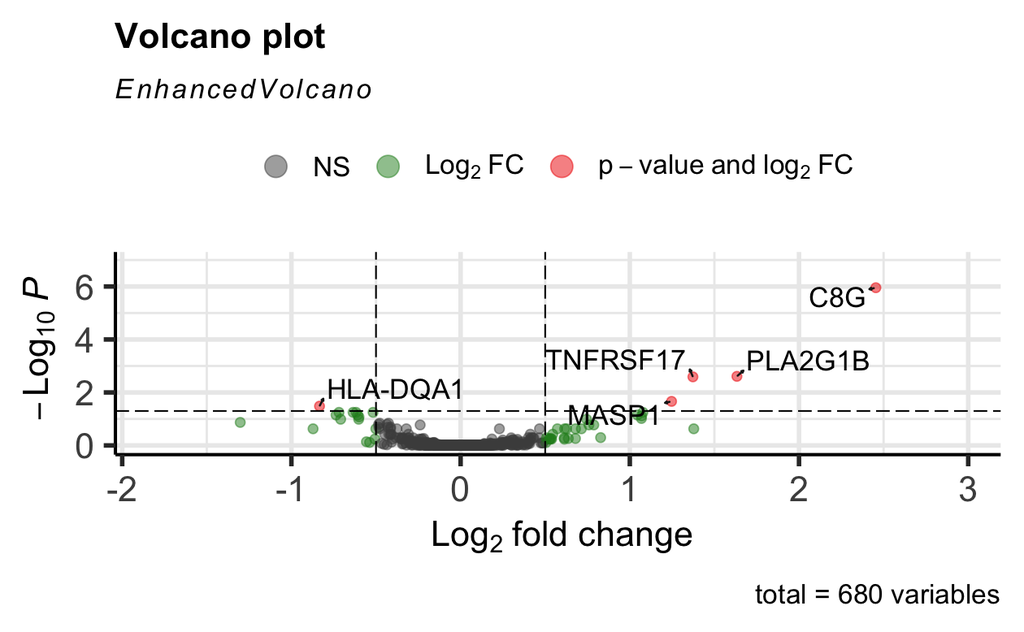

```r
res <- results(dds)

# Generate volcano plot
significant_genes <- rownames(res)[res$padj < 5e-2 & abs(res$log2FoldChange) > 0.5 & !is.na(res$padj)]
vol <- EnhancedVolcano(res, x = "log2FoldChange", y = "padj", lab = rownames(res), selectLab = significant_genes,
                       pCutoff = 5e-2, FCcutoff = 0.5, drawConnectors = TRUE, widthConnectors = 0.5, max.overlaps = 10,
                       xlim = c(min(res$log2FoldChange, na.rm = TRUE) - 0.5, max(res$log2FoldChange, na.rm = TRUE) + 0.5),
                       ylim = c(0, max(-log10(res$padj), na.rm = TRUE) + 1))
print(vol)
```

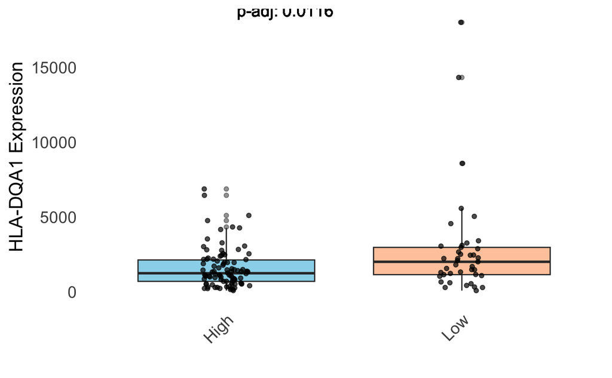

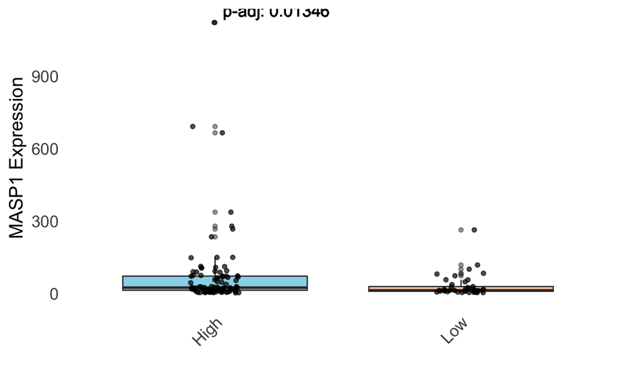

```r
#ggsave("/Users/eemanabbasi/Desktop/Plots/volcano.jpeg", plot = vol, device = "jpeg", width = 20, height = 15)

# Extract normalized counts
immune_counts <- t(as.data.frame(counts(dds, normalized = TRUE)))

# Identify enriched genes and subset data
res$p_log <- -log10(res$padj)
enriched_indices <- which((res$log2FoldChange > 0.5 | res$log2FoldChange < -0.5) & res$p_log >= 1.30103 & !is.na(res$p_log))
enriched_genes <- rownames(res)[enriched_indices]
up_immune_stad <- immune_counts[, enriched_indices]
up_stad_metadata <- filt_clr_ps$ps_tumor_filtered@sam_data[rownames(up_immune_stad), ]
up_filt_otu <- filt_clr_ps$ps_tumor_filtered@otu_table[, rownames(up_stad_metadata)]

# Prepare group membership
group_membership_up <- as.data.frame(up_stad_metadata$Group)
rownames(group_membership_up) <- rownames(up_stad_metadata)

# Extract samples by group
high_samples <- rownames(up_immune_stad[up_stad_metadata$Group == "High", ])
low_samples <- rownames(up_immune_stad[up_stad_metadata$Group == "Low", ])

# Generate box plots for significant genes
sigGenes <- list()
path_to_save <- "/Users/eemanabbasi/Desktop/Plots/"  # Define save path
for (gene in colnames(up_immune_stad)) {
  high_gene_expression <- up_immune_stad[high_samples, gene]
  low_gene_expression <- up_immune_stad[low_samples, gene]

  # Wilcoxon test for significance
  test_result <- wilcox.test(high_gene_expression, low_gene_expression)
  p_value <- test_result$p.value
  adjusted_p_values <- p.adjust(p_value, method = "fdr")

  # Prepare data for plotting
  gene_data <- data.frame(Expression = c(high_gene_expression, low_gene_expression),
                          Group = factor(rep(c("High", "Low"), c(length(high_gene_expression), length(low_gene_expression)))))

  # Create and save box plot if significant
  if (adjusted_p_values < 0.05) {
    file_name <- paste0(path_to_save, gene, ".jpeg")
    y <- ggplot(gene_data, aes(x = Group, y = Expression, fill = Group)) +
      geom_boxplot(alpha = 0.5) +
      geom_jitter(width = 0.1, alpha = 0.7, color = "black") +
      labs(x = "", y = paste0(gene, " Expression")) +
      theme_minimal(base_size = 16) +
      theme(axis.line = element_blank(), axis.text.x = element_text(angle = 45, hjust = 1, size = 14),
            axis.text.y = element_text(size = 14), panel.grid.major = element_blank(),
            panel.grid.minor = element_blank(), panel.border = element_blank(), legend.position = "none") +
      scale_fill_manual(values = c("Low" = "#FD9347", "High" = "#00AED7")) +
      geom_text(aes(x = 1.25, y = max(gene_data$Expression),
                    label = paste("p-adj:", signif(adjusted_p_values, digits = 4))),
                vjust = -0.5, hjust = 0.5, size = 5, color = "black")
    print(y)
    #ggsave(file_name, plot = y, width = 6, height = 6, dpi = 300)
  }
}
```

```r
# Gene Set Enrichment Analysis for the significant genes
enriched_genes <- c("C8G", "HLA-DQA1", "MASP1", "PLA2G1B", "TNFRSF17")
group_identity <- c("High", "Low", "High", "High", "High")
data <- data.frame(Gene = enriched_genes, Group = group_identity)
go_enrichment <- enrichGO(gene = data$Gene, OrgDb = org.Hs.eg.db, keyType = "SYMBOL", ont = "BP",
                          pAdjustMethod = "BH", pvalueCutoff = 0.05, qvalueCutoff = 0.05)

# Extract pathway descriptions for enriched genes
pathway_descriptions <- vector("list", length = length(enriched_genes))
names(pathway_descriptions) <- enriched_genes
for (i in seq_along(go_enrichment@result$Description)) {
  genes_in_pathway <- strsplit(go_enrichment@result$geneID[i], "/")[[1]]
  pathway_desc <- go_enrichment@result$Description[i]
  for (gene_id in genes_in_pathway) {
    if (gene_id %in% enriched_genes) {
      pathway_descriptions[[gene_id]] <- paste(pathway_descriptions[[gene_id]], pathway_desc, sep = "; ")
    }
  }
}
pathway_descriptions <- unlist(pathway_descriptions)
gene_pathway_table <- data.frame(Gene_ID = names(pathway_descriptions), Pathway_Description = pathway_descriptions, stringsAsFactors = FALSE)

#Find pathway for a specific gene
gene_to_find = "TNFRSF17"

for (i in 1:nrow(go_enrichment@result)) {
  # Check if the gene ID in the current row matches the specified gene
  if (go_enrichment@result[i, "geneID"] == gene_to_find) {
    # If there's a match, extract the pathway description
    pathway_description <- go_enrichment@result[i, "Description"]
    # Break the loop since we found the description
    break
  }
}

pathway_description
```

```
[1] "lymphocyte homeostasis"
```